# Leverage and Margin

Kevin Crotty  
BUSI 448: Investments

## Leverage

**Leverage** is investing borrowed money.

- The return, good or bad, on every $1 of your own money is amplified.

## Example

| Assets |  | Liab/Eq |  |
| --- | --- | --- | --- |
| Stocks | 150,000 | Debt Equity | 50,000 100,000 |
| Total | 150,000 | Total | 150,000 |

- Leverage ratio $=\frac{\text{Assets}}{\text{Equity}}$
- Example is levered 1.5 to 1
- More jargon: 50% leverage

## One possible future

Suppose: - the stocks go up 10% - you’re charged 2% interest on the loan (rolled into the debt balance)

| Assets |  | Liab/Eq |  |
| --- | --- | --- | --- |
| Stocks | 165,000 | Debt Equity | 51,000 114,000 |
| Total | 165,000 | Total | 165,000 |

- The return is 14% (114,000/100,000-1).
- You made 10% plus one half of (10% minus 2%) $= 0.10 + 0.5(0.10-0.02) = 0.14$
- “one-half” because you borrowed 50%.

## Levered return

Let $w = \frac{\text{Debt}}{\text{Initial Equity}}$.

We can rewrite this as:

$$r_{\text{stock}} + w \cdot (r_{\text{stock}} - r_{\text{borrow}})\,.$$

The return in the example is:

$$0.10 + 0.5(0.10-0.02) = 0.14$$

## Another possible future

- Suppose the stocks fell by 10%.
- You lose 10% plus one half of ($-$ 10% $-$ 2% ).
- So, your loss is 16% on your $100,000 investment.

| Assets |  | Liab/Eq |  |
| --- | --- | --- | --- |
| Stocks | 135,000 | Debt Equity | 51,000 84,000 |
| Total | 135,000 | Total | 135,000 |

- Check: 84,000/100,000 -1 = -16%.

## The good and the bad

- You always make the stock return plus the fraction borrowed times (stock return minus borrowing rate).
- With 50% leverage and a 2% interest charge,

$$+10\text{%} \rightarrow +14\text{%}$$

$$-10\text{%} \rightarrow -16\text{%}$$

## Levered S&P Returns

- SPY with leverage in today’s notebook

## Margin

**Margin**: borrowing from your broker to purchase securities

- Percent margin = $\frac{\text{Equity}}{\text{Total Asset Value}}$
- **Initial margin** requirement set by the Fed’s Reg T: 50%
  - Broker may set a higher initial margin requirement
- **Maintenance margin** requirement set by broker
  - Protects broker agains default by borrower if asset values drop.

## Example with margin

Initial balance sheet

| Assets |  | Liab/Eq |  |
| --- | --- | --- | --- |
| Stocks | 150,000 | Margin loan Equity | 50,000 100,000 |
| Total | 150,000 | Total | 150,000 |

$$\begin{align*}
\text{Percent Margin} &= \frac{\text{Equity}}{\text{Total Asset Value}} \\
&= \frac{100,000}{150,000} \\
&= 66.67\%
\end{align*}$$

## Example with price drop of 10%

Balance sheet after stocks drop by 10% (and margin interest of 2% rolled into loan)

| Assets |  | Liab/Eq |  |
| --- | --- | --- | --- |
| Stocks | 135,000 | Margin loan Equity | 51,000 84,000 |
| Total | 135,000 | Total | 135,000 |

$$\begin{align*}
\text{Percent Margin} &= \frac{\text{Equity}}{\text{Total Asset Value}} \\
&= \frac{84,000}{135,000} \\
&= 62.22\%
\end{align*}$$

## Margin Calls

A **margin call** occurs when the percent margin falls below the maintenance margin set by the broker.

- Suppose the maintenance margin on the account in our example is 35%.
- How much could the stock value drop before a margin call occurs? (Ignore the interest expense on the margin loan.)

A margin call occurs when:

$$\frac{\text{Equity}}{\text{Total Asset Value}} < \text{Maintenance Margin}\,.$$

## Margin Calls

- $S_0$ = initial stock value
- $L$ = margin loan amount
- $MM$ = maintenance margin percentage
- $r$ = stock return

A margin call occurs when:

$$\frac{S_0(1+r) - L}{S_0(1+r)} < MM\,.$$

Solving for $r$:

$$r < \frac{L}{S_0(1-MM)} - 1.$$

## Example

Margin call occurs if stock return is less than:

$$r < \frac{50,000}{150,000(1-0.35)} - 1 = -48.7\%$$

Balance sheet with -50% return

| Assets |  | Liab/Eq |  |
| --- | --- | --- | --- |
| Stocks | 75,000 | Margin loan Equity | 50,000 25,000 |
| Total | 75,000 | Total | 75,000 |

$$\text{Percent Margin} = \frac{25,000}{75,000} = 33.3\%$$

## Margin Loan Rates

- It pays to shop around.
- Interactive Brokers charges
  - [Fed Funds rate](https://fred.stlouisfed.org/series/FEDFUNDS) plus 1.5% on the first $100,000.
  - and falling further after that.
- [Fidelity rate schedule](https://www.fidelity.com/trading/margin-loans/margin-rates)

# Repurchase agreements

## Repurchase agreements (repos)

- Simultaneously sell a security and agree to repurchase the same, or similar, asset at a later date at an agreed price.
- A repo can be thought of as a collateralized loan
  - cash borrower pays the lender interest at the repo rate.
- Initial collateral is usually greater than the notional loan amount.
  - difference is a haircut or repo margin.

## Repo transaction

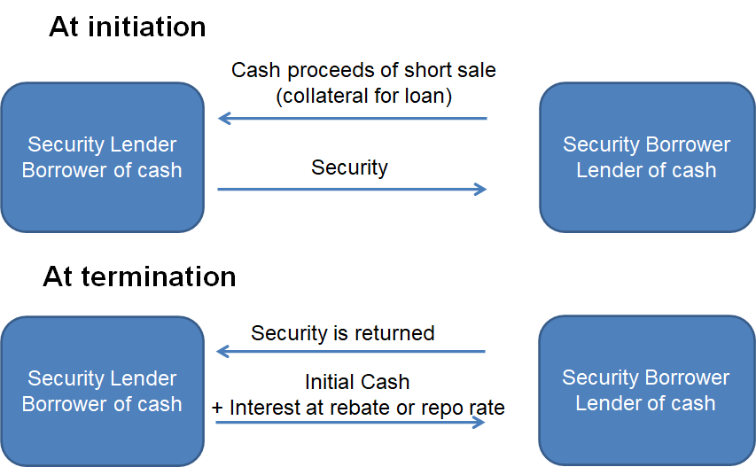

## Repo rates

$$\text{Repo rate} = \text{short-term rate} - \text{collateral-specific fee}$$

- **General collateral**: repo rates slightly below federal funds rate
- **Special collateral**: repo rates lower because cash lender (security borrower) wants a particular security
- Repo rates are lower:
  - higher credit quality bonds
  - more liquid bonds
  - harder to find bonds

## Term of repos

- Repos are short-term
- Majority are overnight

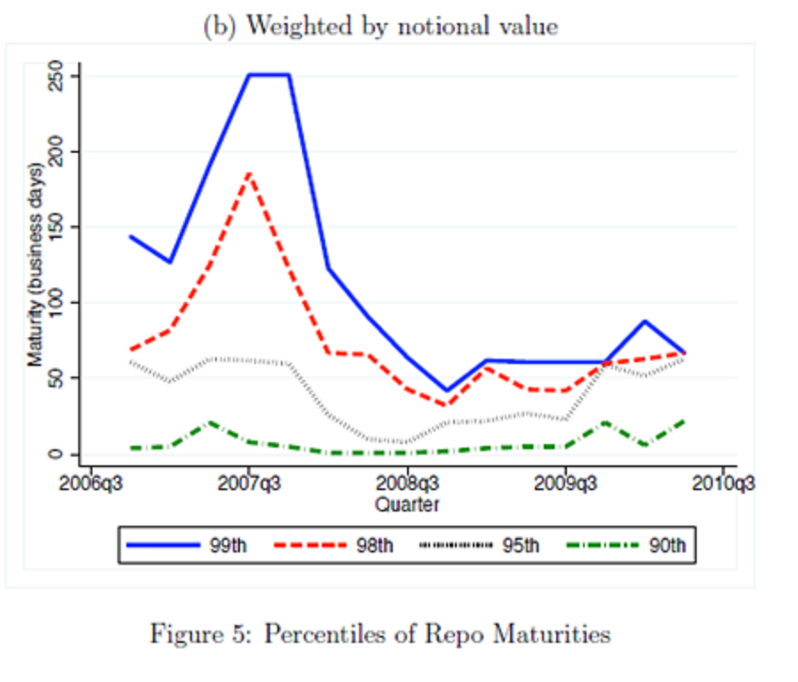

Source: Krishnamurthy, Nagel, Orlov

## Numerical example

- A dealer needs to finance $20 million par value of 10-year Treasury notes for 1 day. The current market value of the securities is $19,576,026.65. A corporation is willing to take the other side of the repo at a repo rate of 6% with a 1% haircut.
- At initiation, the dealer surrenders the notes and receives $19,380,266.39 ($19,576,026.65*99%) in cash.
- In 1 day, the corporation returns the notes and is paid $19,383,496.43 in cash. The interest on the cash loan is calculated
  $$3,230.04 = 19,380,266.39 * 6% * (1/360).$$

## Credit risk and repos

- Both parties are exposed to credit risk.
- The cash lender is exposed to the possibility of default on the cash borrower’s part.
  - If the market value of the collateral declines, the lender may have a loss.
- The cash borrower is exposed to the possibility that the cash lender cannot return the collateral (if the market value of the collateral increases)

## Mitigating credit risks

- The haircut is designed to protect the cash lender. If the collateral market value declines, the lender may still be made whole if the drop is less than the haircut.
- Higher haircuts for
  - riskier borrowers
  - less liquid collateral
- Marking-to-market
  - if collateral MV declines, cash borrower can send cash or additional securities to the cash lender.
  - if collateral MV increases, cash lender can send cash or the collateral securities to the cash borrower

## Empirical evidence on haircuts

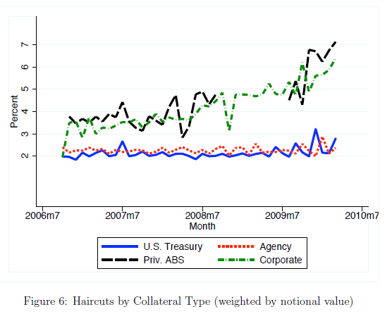

Source: Krishnamurthy, Nagel, Orlov

BUSI 448